# Stroke Prediction

Maroua

2022-03-24

## Classifier for Stroke Prediction Data set

Exploring the data and identifying the most relevant features to our prediction

## Load and display summary of data

```r
data <- read.csv(file = 'healthcare-dataset-stroke-data.csv')
summary(data)
```

```
##        id           gender               age         hypertension
##  Min.   :   67   Length:5110        Min.   : 0.08   Min.   :0.00000
##  1st Qu.:17741   Class :character   1st Qu.:25.00   1st Qu.:0.00000
##  Median :36932   Mode  :character   Median :45.00   Median :0.00000
##  Mean   :36518                      Mean   :43.23   Mean   :0.09746
##  3rd Qu.:54682                      3rd Qu.:61.00   3rd Qu.:0.00000
##  Max.   :72940                      Max.   :82.00   Max.   :1.00000
##  heart_disease     ever_married        work_type         Residence_type
##  Min.   :0.00000   Length:5110        Length:5110        Length:5110
##  1st Qu.:0.00000   Class :character   Class :character   Class :character
##  Median :0.00000   Mode  :character   Mode  :character   Mode  :character
##  Mean   :0.05401
##  3rd Qu.:0.00000
##  Max.   :1.00000
##  avg_glucose_level     bmi            smoking_status         stroke
##  Min.   : 55.12    Length:5110        Length:5110        Min.   :0.00000
##  1st Qu.: 77.25    Class :character   Class :character   1st Qu.:0.00000
##  Median : 91.89    Mode  :character   Mode  :character   Median :0.00000
##  Mean   :106.15                                          Mean   :0.04873
##  3rd Qu.:114.09                                          3rd Qu.:0.00000
##  Max.   :271.74                                          Max.   :1.00000
```

## Data cleaning

ID is not relevant so it should be removed

```r
stroke = subset(data, select = -c(id))
```

BMI should be converted to numeric instead of characters and check fo NA in all data-set

```r
stroke$bmi <- as.numeric(as.character(stroke$bmi))
colSums(is.na(stroke))
```

```
##            gender               age      hypertension     heart_disease
##                 0                 0                 0                 0
##      ever_married         work_type    Residence_type avg_glucose_level
##                 0                 0                 0                 0
##               bmi    smoking_status            stroke
##               201                 0                 0
```

```r
stroke$bmi <- stroke$bmi %>% replace_na(median(stroke$bmi, na.rm = TRUE))
```

The gender feature has one ‘Other’ class, we will replace it by most frequent gender which is ‘female’

```r
stroke$gender[stroke$gender == 'Other'] = 'Female'
```

Same thing with Smoking

```r
as.data.frame(table(stroke$smoking_status))
```

| Var1 | Freq |
| --- | --- |
| formerly smoked | 885 |
| never smoked | 1892 |
| smokes | 789 |
| Unknown | 1544 |

We can see that Unknown has a significantly large number but it does not give any information, so we need to replace it with the most frequent category ‘never smoked’

```r
stroke <- stroke %>% mutate(smoking_status = replace(smoking_status, smoking_status == "Unknown", "never smoked"))
```

Now we can see that our data is clean

```r
colSums(is.na(stroke))
```

```
##            gender               age      hypertension     heart_disease
##                 0                 0                 0                 0
##      ever_married         work_type    Residence_type avg_glucose_level
##                 0                 0                 0                 0
##               bmi    smoking_status            stroke
##                 0                 0                 0
```

## Correlation and feature relevancy

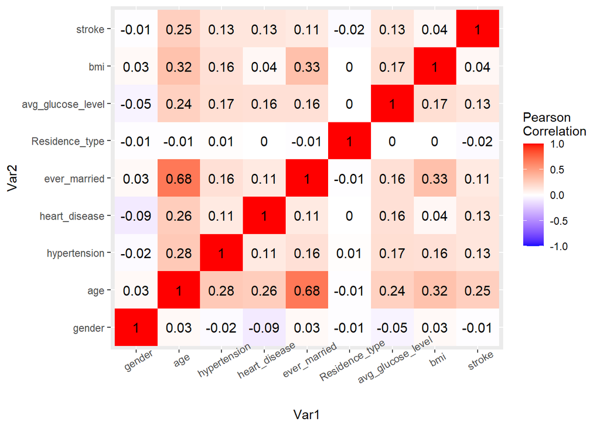

```r
copie = copy(stroke)

#Trensform all characters in features to binary 1/0 for coorealtion

copie$Residence_type[copie$Residence_type == "Urban"] <- 0
copie$Residence_type[copie$Residence_type == "Rural"] <- 1
copie$ever_married[copie$ever_married == "Yes"] <- 1
copie$ever_married[copie$ever_married == "No"] <- 0
copie$gender[copie$gender == "Male"] <- 0
copie$gender[copie$gender == "Female"] <- 1


copie$Residence_type <- as.numeric(as.character(copie$Residence_type))
copie$ever_married <- as.numeric(as.character(copie$ever_married))
copie$gender <- as.numeric(as.character(copie$gender))


# Quantitative Variables: Correlation Map
stroke.quant = subset(copie, select = -c(work_type, smoking_status))
stroke.cor = round(cor(stroke.quant),2)
ggplot(data = reshape2::melt(stroke.cor),aes(x=Var1, y=Var2, fill=value)) + geom_tile() +  scale_fill_gradient2(low = "blue", high = "red", mid = "white", midpoint = 0, limit = c(-1,1), space = "Lab", name="Pearson\nCorrelation") + geom_text(aes(Var2, Var1, label = value), color = "black", size = 4) + theme(axis.text.x = element_text(angle = 30))
```

## Plotting Data

Here we can see different distribution across discrete data

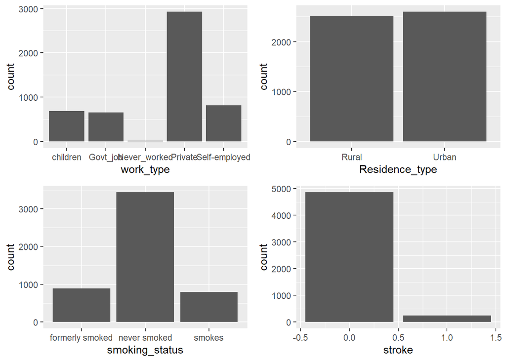

```r
p1 <-ggplot(data = stroke) +geom_bar(mapping = aes(x = work_type))
p2 <-ggplot(data = stroke) +geom_bar(mapping = aes(x = Residence_type))
p3 <-ggplot(data = stroke) +geom_bar(mapping = aes(x = smoking_status))
p4 <-ggplot(data = stroke) +geom_bar(mapping = aes(x = stroke))
grid.arrange(p1,p2,p3,p4, ncol= 2)
```

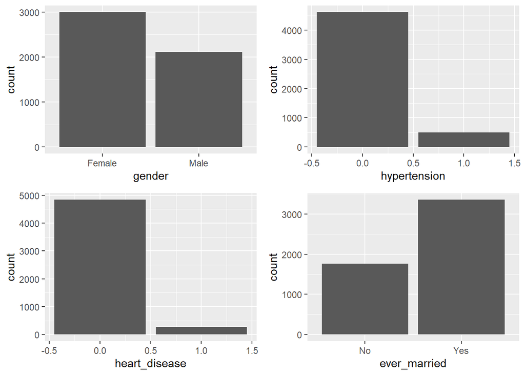

```r
p1 <- ggplot(data = stroke) +geom_bar(mapping = aes(x = gender))
p2 <-ggplot(data = stroke) +geom_bar(mapping = aes(x = hypertension))
p3 <-ggplot(data = stroke) +geom_bar(mapping = aes(x = heart_disease))
p4 <-ggplot(data = stroke) +geom_bar(mapping = aes(x = ever_married))
grid.arrange(p1,p2,p3,p4, ncol= 2)
```

Below we ll plot continuous data

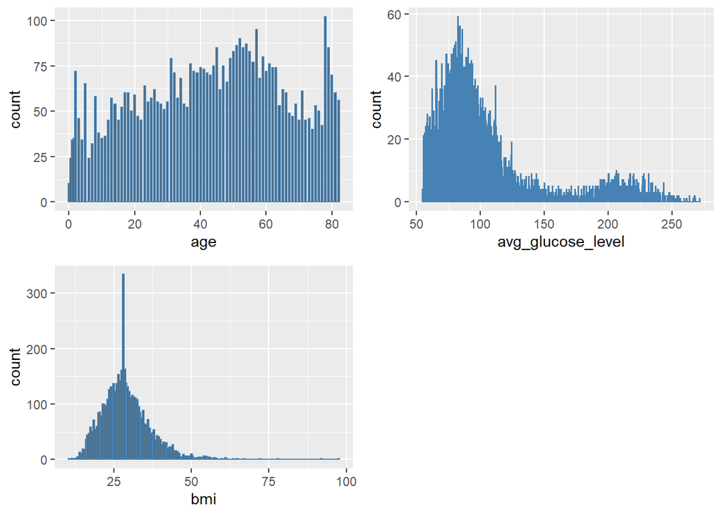

```r
c1 <- ggplot(data = stroke) + geom_histogram(mapping = aes(x = age), binwidth = 0.5, col = 'steelblue')
c2 <- ggplot(data = stroke) + geom_histogram(mapping = aes(x = avg_glucose_level), binwidth = 0.5, col = 'steelblue')
c3 <- ggplot(data = stroke) + geom_histogram(mapping = aes(x = bmi), binwidth = 0.5, col = 'steelblue')
grid.arrange(c1,c2,c3, ncol= 2)
```

Here are different histograms for BMI, glucose level and age.

## Fitting the GLM

First we need our data to be binary for the glm model with some features extended, like smoking and work type because they have implicitly classes too (like we saw in correlation)

```r
stroke_dummy <- dummy_cols(stroke,select_columns = c("gender","work_type","smoking_status"),remove_first_dummy = TRUE, remove_selected_columns = TRUE)
stroke_dummy %>% head
```

|  | age | hypertension | heart_disease | ever_married | Residence_type | avg_glucose_level | bmi | stroke | gender_Male | work_type_Govt_job | work_type_Never_worked | work_type_Private | work_type_Self-employed | smoking_status_never smoked | smoking_status_smokes |
| --- | --- | --- | --- | --- | --- | --- | --- | --- | --- | --- | --- | --- | --- | --- | --- |
| 1 | 67 | 0 | 1 | Yes | Urban | 228.69 | 36.6 | 1 | 1 | 0 | 0 | 1 | 0 | 0 | 0 |
| 2 | 61 | 0 | 0 | Yes | Rural | 202.21 | 28.1 | 1 | 0 | 0 | 0 | 0 | 1 | 1 | 0 |
| 3 | 80 | 0 | 1 | Yes | Rural | 105.92 | 32.5 | 1 | 1 | 0 | 0 | 1 | 0 | 1 | 0 |
| 4 | 49 | 0 | 0 | Yes | Urban | 171.23 | 34.4 | 1 | 0 | 0 | 0 | 1 | 0 | 0 | 1 |
| 5 | 79 | 1 | 0 | Yes | Rural | 174.12 | 24.0 | 1 | 0 | 0 | 0 | 0 | 1 | 1 | 0 |
| 6 | 81 | 0 | 0 | Yes | Urban | 186.21 | 29.0 | 1 | 1 | 0 | 0 | 1 | 0 | 0 | 0 |

```r
sample <- sample(c(TRUE, FALSE), nrow(stroke_dummy), replace=TRUE, prob=c(0.7,0.3))
training <- stroke_dummy[sample,]
testing <- stroke_dummy[-sample,]

model <- glm(stroke ~.,family=binomial(link='logit'), data=training)

summary(model)
```

```
##
## Call:
## glm(formula = stroke ~ ., family = binomial(link = "logit"),
##     data = training)
##
## Deviance Residuals:
##     Min       1Q   Median       3Q      Max
## -1.1665  -0.3353  -0.1744  -0.0933   3.6525
##
## Coefficients:
##                                 Estimate Std. Error z value Pr(>|z|)
## (Intercept)                    -6.660582   1.069737  -6.226 4.77e-10 ***
## age                             0.070873   0.006534  10.847  < 2e-16 ***
## hypertension                    0.505772   0.192054   2.633 0.008451 **
## heart_disease                   0.148323   0.230145   0.644 0.519266
## ever_marriedYes                -0.231404   0.253007  -0.915 0.360393
## Residence_typeUrban             0.047320   0.161224   0.294 0.769137
## avg_glucose_level               0.004645   0.001383   3.358 0.000784 ***
## bmi                            -0.010651   0.013661  -0.780 0.435592
## gender_Male                    -0.081986   0.167068  -0.491 0.623612
## work_type_Govt_job             -0.211273   1.107938  -0.191 0.848769
## work_type_Never_worked        -10.052153 362.243534  -0.028 0.977862
## work_type_Private              -0.232767   1.095979  -0.212 0.831808
## `work_type_Self-employed`      -0.713876   1.116934  -0.639 0.522732
## `smoking_status_never smoked`  -0.176976   0.189244  -0.935 0.349698
## smoking_status_smokes           0.052923   0.255984   0.207 0.836211
## ---
## Signif. codes:  0 '***' 0.001 '**' 0.01 '*' 0.05 '.' 0.1 ' ' 1
##
## (Dispersion parameter for binomial family taken to be 1)
##
##     Null deviance: 1448.7  on 3560  degrees of freedom
## Residual deviance: 1157.2  on 3546  degrees of freedom
## AIC: 1187.2
##
## Number of Fisher Scoring iterations: 14
```

### Prediction for the GLM

```r
model.prob = predict(model, testing, type="response")
predictions <- as.factor(as.numeric(model.prob>0.5))
cm <- confusionMatrix((data = predictions), reference = as.factor(testing$stroke))

show(cm)
```

```
## Confusion Matrix and Statistics
##
##           Reference
## Prediction    0    1
##          0 4861  246
##          1    0    2
##
##                Accuracy : 0.9518
##                  95% CI : (0.9456, 0.9576)
##     No Information Rate : 0.9515
##     P-Value [Acc > NIR] : 0.465
##
##                   Kappa : 0.0152
##
##  Mcnemar's Test P-Value : <2e-16
##
##             Sensitivity : 1.000000
##             Specificity : 0.008065
##          Pos Pred Value : 0.951831
##          Neg Pred Value : 1.000000
##              Prevalence : 0.951458
##          Detection Rate : 0.951458
##    Detection Prevalence : 0.999609
##       Balanced Accuracy : 0.504032
##
##        'Positive' Class : 0
##
```

### Accuracy and other metrics

```r
cm = as.matrix(table(Actual = testing$stroke, Predicted = predictions)) # create the confusion matrix
show(cm)
```

```
##       Predicted
## Actual    0    1
##      0 4861    0
##      1  246    2
```

```r
n = sum(cm) # number of instances

nc = nrow(cm) # number of classes

diagy = diag(cm) # number of correctly classified instances per class

rowsums = apply(cm, 1, sum) # number of instances per class

colsums = apply(cm, 2, sum) # number of predictions per class

p = rowsums / n # distribution of instances over the actual classes

q = colsums / n # distribution of instances over the predicte
```

```r
accuracy = sum(diagy) / n
cat("accuracy:\n")
```

```
## accuracy:
```

```r
show(accuracy)
```

```
## [1] 0.9518497
```

```r
precision = diagy / colsums
cat("\n precision :\n")
```

```
##
##  precision :
```

```r
show(precision)
```

```
##         0         1
## 0.9518308 1.0000000
```

```r
recall = diagy / rowsums
cat("\nrecall :\n")
```

```
##
## recall :
```

```r
show(recall)
```

```
##           0           1
## 1.000000000 0.008064516
```

```r
f1 = 2 * precision * recall / (precision + recall)
cat("\nf1 :\n")
```

```
##
## f1 :
```

```r
show(f1)
```

```
##        0        1
## 0.975321 0.016000
```

### Notes:

Although the accuracy is really good, but the data is unbalanced -> the model behaves good predicting negatives but really bad predicting positives.

One way to overcome this is to increase the number of samples for the (strokes = 1) which we cannot do here.

Another method is called oversampling (it takes the minority class and duplicate random samples of it)

and this will be applied at the end to try to improve the predictions.

## Applying KNN (nearest neighbor)

```r
train_control <- trainControl(method = "cv", number = 5)
knn <- train(stroke~., data = training, method = "knn", trControl = train_control)
knn
```

```
## k-Nearest Neighbors
##
## 3561 samples
##   14 predictor
##
## No pre-processing
## Resampling: Cross-Validated (5 fold)
## Summary of sample sizes: 2849, 2849, 2849, 2849, 2848
## Resampling results across tuning parameters:
##
##   k  RMSE       Rsquared    MAE
##   5  0.2377227  0.01592031  0.09415116
##   7  0.2301069  0.02100599  0.09286822
##   9  0.2268490  0.02463483  0.09317175
##
## RMSE was used to select the optimal model using the smallest value.
## The final value used for the model was k = 9.
```

## Oversampling data

```r
library(ROSE)
data_balanced_over <- ovun.sample(stroke ~ ., data = stroke, method = "over",N = 5500)$data

stroke_dummy <- dummy_cols(data_balanced_over,select_columns = c("gender","work_type","smoking_status"),remove_first_dummy = TRUE, remove_selected_columns = TRUE)

sample <- sample(c(TRUE, FALSE), nrow(stroke_dummy), replace=TRUE, prob=c(0.7,0.3))
training <- stroke_dummy[sample,]
testing <- stroke_dummy[-sample,]

model <- glm(stroke ~.,family=binomial(link='logit'), data=training)

model.prob = predict(model, testing, type="response")
predictions <- as.factor(as.numeric(model.prob>0.5))
cm2 <- confusionMatrix((data = predictions), reference = as.factor(testing$stroke))

show(cm2)
```

```
## Confusion Matrix and Statistics
##
##           Reference
## Prediction    0    1
##          0 4803  572
##          1   57   67
##
##                Accuracy : 0.8856
##                  95% CI : (0.8769, 0.8939)
##     No Information Rate : 0.8838
##     P-Value [Acc > NIR] : 0.3463
##
##                   Kappa : 0.1433
##
##  Mcnemar's Test P-Value : <2e-16
##
##             Sensitivity : 0.9883
##             Specificity : 0.1049
##          Pos Pred Value : 0.8936
##          Neg Pred Value : 0.5403
##              Prevalence : 0.8838
##          Detection Rate : 0.8734
##    Detection Prevalence : 0.9775
##       Balanced Accuracy : 0.5466
##
##        'Positive' Class : 0
##
```

### Accuracy and other metrics

```r
cm = as.matrix(table(Actual = testing$stroke, Predicted = predictions)) # create the confusion matrix
show(cm)
```

```
##       Predicted
## Actual    0    1
##      0 4803   57
##      1  572   67
```

```r
n = sum(cm) # number of instances

nc = nrow(cm) # number of classes

diagy = diag(cm) # number of correctly classified instances per class

rowsums = apply(cm, 1, sum) # number of instances per class

colsums = apply(cm, 2, sum) # number of predictions per class

p = rowsums / n # distribution of instances over the actual classes

q = colsums / n # distribution of instances over the predicte
```

```r
accuracy = sum(diagy) / n
cat("accuracy:\n")
```

```
## accuracy:
```

```r
show(accuracy)
```

```
## [1] 0.8856156
```

```r
precision = diagy / colsums
cat("\n precision :\n")
```

```
##
##  precision :
```

```r
show(precision)
```

```
##         0         1
## 0.8935814 0.5403226
```

```r
recall = diagy / rowsums
cat("\nrecall :\n")
```

```
##
## recall :
```

```r
show(recall)
```

```
##         0         1
## 0.9882716 0.1048513
```

```r
f1 = 2 * precision * recall / (precision + recall)
cat("\nf1 :\n")
```

```
##
## f1 :
```

```r
show(f1)
```

```
##         0         1
## 0.9385442 0.1756225
```

## Comparison

### Before oversampling ,Then: after oversampling

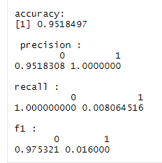

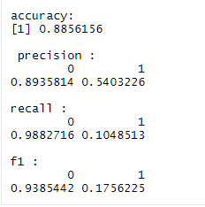